# Activity 09: Dimension Reduction: Principal Components Analysis (PCA)

Jerome Poblete

2026 June 18

# A. Principal Components

## 2. Read in the frogs’ data as a dataframe

```r
frog.data <- read.csv("../data/Meneses_et.al_2026_Platymantis.csv")
```

## 3. Subset your data to retain only the “Species” column and morphological features

E.g. SVL, HL, SNL, etc., from columns 10 through the last one (i.e. 10:X).

```r
frog.numeric <- frog.data[, 10:ncol(frog.data)]
```

## 4. Check the class & structure of the subset data. How many morphological features are present in the dataset?

```r
library(tidyverse)

class(frog.numeric)
```

```
## [1] "data.frame"
```

```r
structure(frog.numeric)
```

```
##    S.V.L. H.L. SNL  ED  TD E.N IND IOD H.W. forearm femur tibia tarsus foot hand Toe4L Fin1L Fin3L
## 1    13.5  6.2 2.1 1.6 1.1 1.2 1.4 1.7  5.7     3.1   6.6   6.9    4.1  6.0  3.2   4.2   1.3   1.9
## 2    14.5  6.4 2.4 1.5 1.1 1.2 1.6 1.7  6.4     4.5   7.6   7.5    4.6  7.5  3.2   4.1   1.9   2.3
## 3    15.1  6.6 2.8 1.7 1.2 1.6 1.7 1.5  5.7     4.0   7.6   7.8    5.0  7.4  3.7   4.0   1.7   2.2
## 4    15.6  6.7 2.8 1.9 1.1 1.5 1.9 1.7  6.0     4.0   8.9   8.9    5.4  8.1  4.0   5.2   2.2   2.3
## 5    14.2  6.4 2.4 1.5 1.1 1.2 2.1 1.7  5.9     4.0   6.8   6.8    4.6  5.8  3.4   4.1   1.7   2.3
## 6    13.1  6.0 2.5 1.6 1.1 1.5 1.8 1.7  5.9     3.8   7.5   7.2    4.3  6.4  3.1   4.1   1.6   2.0
## 7    14.8  6.4 2.5 2.1 1.0 1.3 2.1 1.9  6.2     4.0   6.9   6.7    4.2  6.0  3.4   4.6   1.8   1.9
## 8    15.3  6.3 2.5 1.6 1.2 1.7 1.7 2.2  6.6     4.2   9.1   8.0    5.3  7.6  3.5   4.4   1.5   1.7
## 9    14.6  5.7 2.4 1.7 1.3 1.5 1.7 2.1  6.0     4.0   7.6   6.7    4.6  6.8  3.1   4.4   2.0   1.8
## 10   16.5  6.0 2.4 2.0 1.1 1.2 1.8 1.9  6.8     4.0   8.0   7.8    4.6  7.5  3.3   4.3   1.4   1.9
## 11   18.2  7.5 2.7 2.0 1.5 1.5 2.3 2.2  7.7     4.8   8.9   8.8    5.9  8.1  3.8   5.9   2.2   2.6
## 12   12.3  5.2 2.1 1.4 1.0 1.1 1.4 1.5  5.3     3.4   7.8   6.6    3.9  6.2  2.5   3.4   1.5   1.5
## 13   14.2  5.8 2.6 1.8 1.2 1.7 1.8 1.8  6.6     3.9   8.1   7.9    4.9  7.4  3.5   5.2   1.5   1.8
## 14   13.6  6.0 2.3 1.7 1.0 1.3 1.8 1.8  6.6     4.0   8.3   7.7    4.7  7.1  3.2   4.3   1.5   1.7
```

[output cut: 68 more lines]

```r
frog.morph <- frog.numeric |> select(10:ncol(frog.numeric))
length(frog.morph)
```

```
## [1] 16
```

There are 16 morphological feature present in the data set.

## 5. Ensure the data frame has no NAs.

```r
frog.numeric <- frog.numeric[frog.numeric |> complete.cases(), ]
frog.morph   <- frog.morph[frog.morph |> complete.cases(), ]
```

## 6. Scale the data using only the numeric columns, then compute the pairwise correlations. Do not further subset the data.

```r
frog.scaled <- frog.morph  |> scale()
frog.cmat   <- frog.scaled |> cor() |> round(2)
```

## 7. Use the correlation matrix to…

### i. Calculate the following:

1. Eigenvectors

```r
frog.eig <- frog.cmat |> eigen()
frog.eig
```

```
## eigen() decomposition
## $values
##  [1] 5.425610911 2.574463263 1.788009977 1.493856632 1.142106031 1.038220967 0.654201826 0.507218102
##  [9] 0.465565603 0.395047326 0.200887389 0.171221442 0.085004137 0.042734068 0.014043349 0.001808975
##
## $vectors
##              [,1]        [,2]        [,3]         [,4]        [,5]        [,6]        [,7]         [,8]
##  [1,] -0.25851866  0.06313997  0.02174523  0.211918968 -0.05526203  0.25376082  0.77571660  0.096671975
##  [2,] -0.33757611 -0.22578014 -0.17998941  0.042160179  0.02450729  0.22398866 -0.05324721 -0.234024144
##  [3,] -0.32681275 -0.30048060 -0.21784727  0.048732604 -0.04264662  0.07828043 -0.17723464 -0.095942395
##  [4,] -0.35676000 -0.19032797 -0.14705636  0.118408728 -0.04875609  0.10278524 -0.03275904 -0.068256664
##  [5,] -0.35947898 -0.13574753 -0.14221780  0.136455899  0.08216868  0.08582591 -0.18939006  0.006279281
##  [6,] -0.22717873  0.22458445  0.10407535  0.265996935  0.13709586 -0.29032832 -0.44818996  0.043156381
##  [7,] -0.31095373 -0.04833774  0.08955440  0.012392428  0.12294846 -0.12948660  0.00748435  0.851777221
##  [8,] -0.25407448  0.24746040 -0.02977764  0.192725796  0.13800795 -0.29136159  0.17467484 -0.374461683
```

[output cut: 42 more lines]

2. Proportion of variance (percentage)

```r
pvar <- function(x) {
  props <- x / sum(x)
  data.frame(Proportion = props, Percentage = props * 100)
}

frog.pvar <- pvar(frog.eig$values)
frog.pvar |> round(4)
```

```
##    Proportion Percentage
## 1      0.3391    33.9101
## 2      0.1609    16.0904
## 3      0.1118    11.1751
## 4      0.0934     9.3366
## 5      0.0714     7.1382
## 6      0.0649     6.4889
## 7      0.0409     4.0888
## 8      0.0317     3.1701
## 9      0.0291     2.9098
## 10     0.0247     2.4690
## 11     0.0126     1.2555
## 12     0.0107     1.0701
## 13     0.0053     0.5313
## 14     0.0027     0.2671
## 15     0.0009     0.0878
## 16     0.0001     0.0113
```

### ii. How many principal components were produced?

```r
frog.scores      <- frog.scaled %*% frog.eig$vectors
frog.scores.head <- frog.scores |> head()
frog.scores.head |> round(4)
```

```
##      [,1]    [,2]    [,3]    [,4]    [,5]    [,6]    [,7]    [,8]   [,9]   [,10]   [,11]   [,12]  [,13]
## 1  1.2883 -2.5055  1.2766 -1.0484 -1.0242 -2.1138 -1.2679 -0.0380 0.6168 -0.3977 -0.0637  0.1882 0.4269
## 2 -2.5424  1.3880 -1.6920  0.8390 -0.4965  0.8445  0.8001 -0.7043 0.6094 -0.4875 -0.9412  0.4362 0.5832
## 3 -2.8983 -0.5776 -0.1124  0.8001 -1.5955 -0.6937 -0.9021 -1.0812 1.4366 -0.3711 -0.1649  0.8029 0.2848
## 4 -4.4776 -1.4520 -2.0265  4.0730  2.1935 -0.3937 -1.4098 -0.0386 0.0316  0.1494  0.2122 -0.3955 0.2160
## 5 -1.1706  1.5533 -0.2062 -0.8097 -1.7153 -0.9628  0.2339 -0.4039 0.9195 -0.3457  0.8824  0.4492 0.4469
## 6 -0.0818 -0.3638 -1.5920 -0.4374  0.2694 -0.0647 -0.0065 -0.3535 0.5702 -0.3056 -0.0767 -0.2614 0.4217
##     [,14]   [,15]   [,16]
## 1  0.2920 -0.0096 -0.0781
## 2  0.1677  0.1803 -0.1525
## 3 -0.1876 -0.1512  0.0227
## 4 -0.1226  0.0297  0.0545
## 5  0.0338  0.0647  0.0029
## 6 -0.1140  0.0200  0.0179
```

```r
frog.scores.head |> nrow()
```

```
## [1] 6
```

### iii. What is the proportion of variance explained by components 1-4?

```r
frog.pvar$Percentage[1:4] |> round(2)
```

```
## [1] 33.91 16.09 11.18  9.34
```

Components 1 through 4 explain 33.91%, 16.09%, 11.18%, and 9.34% of the variance, respectively.

## 8. Create a 1x2 plot showing screeplot & the PCA biplot

You can use either base R or ggplot2. You can be creative here by coloring the point shapes per species and adding a legend Consider the high data-ink ratio you learned from the lecture

### i. Scree Plot

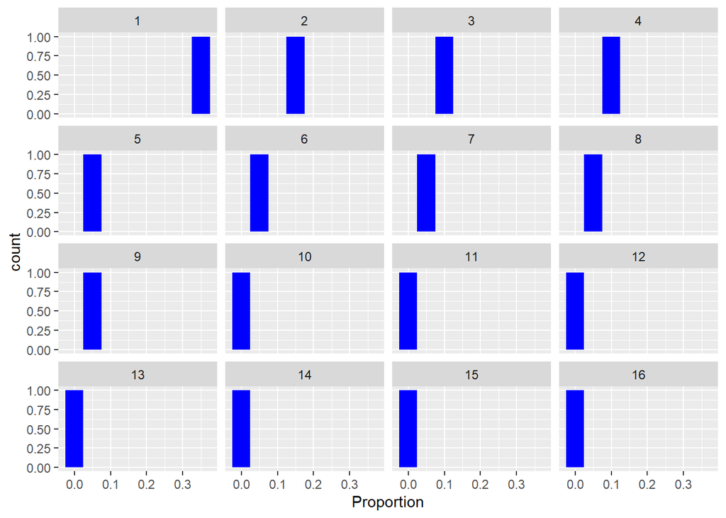

```r
library(ggplot2)

# NOTE: Using the raw proportions vs. percentages will greatly influence
#       what a good bin width would be!
pcs <- paste0("PC", 1:ncol(frog.morph))

ggplot(frog.pvar, aes(Proportion)) +
  facet_wrap(1:16) +
  geom_histogram(binwidth = 0.05, fill = "blue")
```

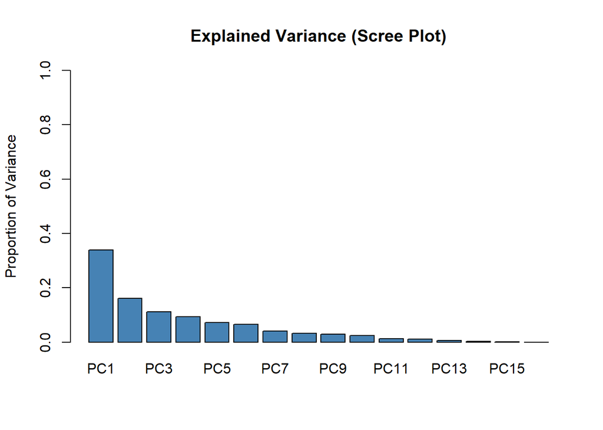

```r
barplot(frog.pvar$Proportion,
        names.arg = pcs,
        ylim = c(0, 1),
        col  = "steelblue",
        main = "Explained Variance (Scree Plot)",
        ylab = "Proportion of Variance")
```

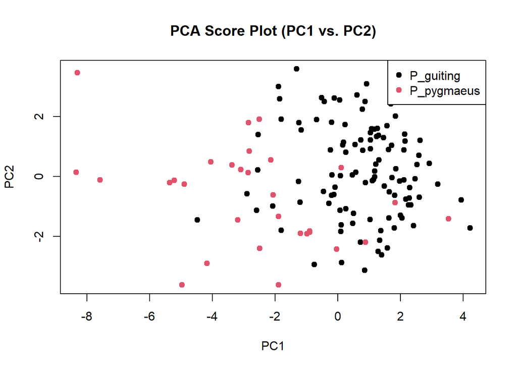

```r
# What the hell are we gonna use as our alternative for iris$Species
# It must be as long as scores[, 1]
plot(frog.scores[, 1], frog.scores[, 2],
     xlab = "PC1", ylab = "PC2",
     main = "PCA Score Plot (PC1 vs. PC2)",
     pch  = 19,
     col  = factor(frog.data$Species))

legend("topright",
       legend = levels(factor(frog.data$Species)),
       col = 1:3,
       pch = 19)
```

# B. Broken-stick vs. PCAtest

## 1. Determine the variance explained by principal components

## 2. Create a barplot showing the results of Broken-stick analysis

Also perform a significance test for principal components using PCAtest, following the instructions at https://arleyc.github.io/PCAtest/.